# Fraud Detection in Auto Insurance Claims

### Visaulization of the Silhouettes

```python
def plot_silhouettes(data, clusters, metric='euclidean'):

    from matplotlib import cm
    from sklearn.metrics import silhouette_samples

    cluster_labels = np.unique(clusters)
    n_clusters = cluster_labels.shape[0]
    silhouette_vals = metrics.silhouette_samples(data, clusters, metric='euclidean')
    c_ax_lower, c_ax_upper = 0, 0
    cticks = []
    for i, k in enumerate(cluster_labels):
        c_silhouette_vals = silhouette_vals[clusters == k]
        c_silhouette_vals.sort()
        c_ax_upper += len(c_silhouette_vals)
        color = cm.jet(float(i) / n_clusters)
        pl.barh(range(c_ax_lower, c_ax_upper), c_silhouette_vals, height=1.0,
                      edgecolor='none', color=color)

        cticks.append((c_ax_lower + c_ax_upper) / 2)
        c_ax_lower += len(c_silhouette_vals)

    silhouette_avg = np.mean(silhouette_vals)
    pl.axvline(silhouette_avg, color="red", linestyle="--")

    pl.yticks(cticks, cluster_labels)
    pl.ylabel('Cluster')
    pl.xlabel('Silhouette coefficient')

    pl.tight_layout()
    #pl.savefig('images/11_04.png', dpi=300)
    pl.show()

    return
```

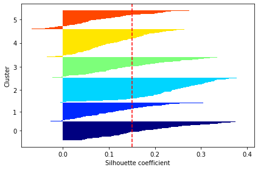

```python
plot_silhouettes(num_features, clusters)
```

- Some of the clusters are largest in size in terms of Silhouette coefficient
- Dotted line is the mean silhouette value
- Some clusters are signifcantly above the mean silhouette value

### Compute the Completeness and Homogeneity values of the generated clusters.

```python
print('Completeness : ', completeness_score(y_train, clusters))
print('Homogeneity  : ', homogeneity_score(y_train, clusters))
```

```
Completeness :  0.012149124861312529
Homogeneity  :  0.03861986585765167
```

- Homogeneity: each cluster contains only members of a single class.
- Completeness: all members of a given class are assigned to the same cluster.
- The completeness score approaches 1 when most of the data points that are members of a given class are elements of the same cluster.
- While the homogeneity score approaches 1 when all the clusters contain almost only data points that are member of a single class.

## Principal Component Analysis (PCA) using Decomposition module in Scikit-learn

Principal Component Analysis (PCA) is a statistical procedure that allows us to summarize the information contained in a large set by means of a smaller set of “summary indices” that can be more easily visualized and analyzed. It is a very common technique for “dimensionality reduction” and finding the “latent/hidden” factors from the data.

- The goal of PCA is to simplify model features into fewer, uncorrelated features to help visualize patterns in the data and help it run faster.
- It reduces the number of variables while maintaining the majority of the important information.
- It can help solve the very common problem of “Curse of Dimensionality”.
- We should only apply PCA to continuous data and the data should be scaled before applying PCA technique.
- PCA can be very helpful in predicting the parameter of interest.
- PCA can help us build the parsimonious model which is easier to explain.
- PCA can also be used in relation with other clustering techniques for better results.

```python
pca = decomposition.PCA(n_components=6)
claims_trans = pca.fit(num_features).transform(num_features)     # transforming the data
```

```python
np.set_printoptions(precision=2,suppress=True)
print(claims_trans)
```

```
[[ 0.09 -0.14  0.05 -0.53 -0.29 -0.07]
 [-0.31 -0.25  0.3   0.02  0.37 -0.11]
 [ 0.59 -0.35  0.17  0.34  0.24 -0.1 ]
 ...
 [ 0.41  0.14 -0.62  0.09 -0.22  0.38]
 [-0.02  0.01  0.49 -0.11  0.25  0.18]
 [-0.16  0.65  0.5  -0.23 -0.25  0.26]]
```

- The rows are still the claims data but the columns are the reduced # of features OR the principal components.
- We can now use these components to cluster our claims data.
- This is something similar to reduced reatures in classification.

### Analyze the principal components to determine the number of PCs needed to capture at least 90% of variance in the data.

```python
# what percentage of variance is explained by these five components
# eigenvalue / sum of all the eigenvalues
print(pca.explained_variance_ratio_)
```

```
[0.28 0.16 0.15 0.13 0.12 0.07]
```

```python
sum(pca.explained_variance_ratio_ * 100)
```

```
90.53794091774775
```

##### Provide a plot of PC variances.

- We can plot the principal components based on the percentage of variance they capture:

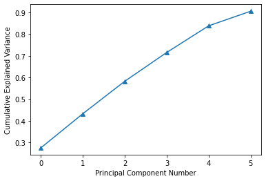

```python
import matplotlib.pyplot as plt
%matplotlib inline

fig = plt.figure()
ax = fig.add_subplot(111)
ax.plot(np.cumsum(pca.explained_variance_ratio_), marker='^')
plt.xlabel('Principal Component Number')
plt.ylabel('Cumulative Explained Variance')
plt.show()
```

- These 6 components account for just over 90% of the variance. Using these 6 components, we can cover most of the essential characteristics of the data.

### d): Kmeans on Transformed Data

##### Perform Kmeans again, but this time on the lower dimensional transformed data.

```python
kmeans.fit(claims_trans)                        # transformed data
```

[output not shown]

[output cut: 199 more lines]

[output not shown]

```
KMeans(max_iter=500, n_clusters=6, verbose=1)
```

```python
# get the actual cluster assignments
# these are the cluster labels associated with each instance in the data
clusters_pca = kmeans.predict(claims_trans)    # here we are not predicting anything but just to match the design pattern
                                               # of other scikit learn function we write predict
```

##### Then compare Silhouette values as well as completeness and Homogeneity values of the new clusters. Compare these results with those obtained on the full data in part b.

```python
# find silhouette values
silhouettes_pca = metrics.silhouette_samples(claims_trans, clusters_pca)  # pass the data and the clusters
print(silhouettes_pca[:20])           # print first twenty values
```

```
[ 0.43  0.07  0.27  0.08  0.14  0.08  0.32  0.03  0.27  0.28 -0.07  0.26  0.09
  0.23  0.08  0.01  0.24  0.14  0.24  0.25]
```

```python
# mean of silhouettes values
# value closest to 1 is better
# we can use different number of k values and compare
print('Mean of silhouettes values on full data   : ', silhouettes.mean())
print('Mean of silhouettes values using PCA      : ', silhouettes_pca.mean())
```

```
Mean of silhouettes values on full data   :  0.14972254040960067
Mean of silhouettes values using PCA      :  0.1677095269120631
```

```python
print('Completeness on full data                 : ', completeness_score(y_train, clusters))
print('Completeness using PCA                    : ', completeness_score(y_train, clusters_pca))
print()
print('Homogeneity on full data                  : ', homogeneity_score(y_train, clusters))
print('Homogeneity using PCA                     : ', homogeneity_score(y_train, clusters_pca))
```

```
Completeness on full data                 :  0.012149124861312529
Completeness using PCA                    :  0.012755436483637712

Homogeneity on full data                  :  0.03861986585765167
Homogeneity using PCA                     :  0.04054020981456376
```

- We can observe from the above comparison that the Mean of silhouettes values improved using lower dimentional transformed data. It means that the quality of clustering has improved.
- However, there is not a very big difference in the completeness and homogeneity values.

The case for doing a cluster analysis (or other dimensionality reduction methods such as PCA) is probably to reduce the number of features in a way that the learning model is more robust. In case of this dataset, we do not have that many number of good numerical variables to group.

Clustering (unsupervised learning technique) comes into the play as our saviour when we do not have data to supervise. It is in general not a good idea to turn supervised learning (classification) into unsupervised learning (clustering) as it will sacrifice the vital information: labels.

## Predictive Modeling and Model Evaluation Using Classification Techniques

We are going to experiment with various classification models provided as part of the scikit-learn (sklearn) machine learning module using the pre-processed insurance claims data set. In particular, we will use the following list of classification algorithms to classify the data:

- K-Nearest-Neighbor (KNN) Classifier
- Naive Bayes (Gaussian) classifier
- Decision Tree Classifier
- Linear Discriminant Analysis (LDA) Classifier
- Rocchio Classifier
- Random Forest Classifier
- Ada Boost Classifier
- Gradient Boosting Classifier
- Support Vector Machines (SVC Classifier)
- Logistic Regression Classifier

The basic objective is to create a best predictive model for classifying fraud, whether a claimant is likely to commit fraud in auto insurance claims. This is a pure classification task which also includes the misclassification costs. In addition to building the best model, we will also generate the confusion matrix (visualize it using Matplotlib), as well as the classification report.

Using GridSearchCV from Scikit-learn, evaluate predictive models on 10-fold cross validation. We will also experiment with GridSearchCV for parameters optimization to see if we can improve accuracy (we will not provide the details of all of our experimentation, but will provide a short discussion on what parameters worked best as well as our final results).

We are using Grid Search because it allows us to explore the parameter space more systematically and lets us select the best tuning parameters (aka "hyperparameters"). Grid Search allows us to define a grid of parameters that are searched using K-fold cross-validation.

Finally, the accuracy of the different models will be compared to select the final model for prediction and the overview of model performances will be presented in a tabulated form.

#### A versatile function to measure performance of a model

```python
def measure_performance(X, y, clf, show_accuracy=True, show_classification_report=True, show_confussion_matrix=True):
    y_pred = clf.predict(X)

    if show_accuracy:
        Accuracy = metrics.accuracy_score(y, y_pred)
        #print("Accuracy: {0:.3f}".format(metrics.accuracy_score(y, y_pred)),"\n")
    if show_classification_report:
        print("===============CLASSIFICATION REPORT===============")
        print(metrics.classification_report(y, y_pred),"\n")

    if show_confussion_matrix:
        print("===============CONFUSION MATRIX===============")
        cm = metrics.confusion_matrix(y, y_pred)
        sns.heatmap(cm, annot = True, cmap = 'copper',fmt='g')
        plt.show()

    return Accuracy
```

#### A versatile function to perform GridSearch on different models

We are going to use the Grid Search to explore the parameter space more systematically. Select the best tuning parameters (aka "hyperparameters"). Grid Search allows us to define a grid of parameters that will be searched using K-fold cross-validation.

```python
# keeping track of the different statistics of all classification models
modeL = []
gsCV_BestScore = []
train_accuracy = []
test_accuracy = []
```

```python
def grid_search_function(m, modelName, params, xtrain, ytrain, xtest, ytest, cv=10):
    'Performs GridSearch and gets different statistics'

    gs = GridSearchCV(m, params, cv=10)             # perform Grid Search CV

    %time _ = gs.fit(xtrain, ytrain)                # print Wall Time of the model
    print()
    print(gs.best_params_, gs.best_score_)          # print best parameters and best cv score
    print()

    train_acu = measure_performance(xtrain, ytrain, gs, show_accuracy=True, show_classification_report=False, show_confussion_matrix=False)
    test_acu = measure_performance(xtest, ytest, gs, show_accuracy=True, show_classification_report=True, show_confussion_matrix=True)

    print("Training Accuracy: {0:.3f}".format(train_acu))          # print training accuracy
    print("Test Accuracy    : {0:.3f}".format(test_acu),"\n")      # print test accuracy

    modeL.append(modelName)                                        # add model name to the list
    gsCV_BestScore.append(gs.best_score_)                          # add best_score to the list
    train_accuracy.append(train_acu)                               # add train accuracy to the list
    test_accuracy.append(test_acu)                                 # add test accuracy to the list
```

### KNN Classifier:

The k-nearest neighbors (KNN) algorithm is a simple, easy-to-implement supervised machine learning algorithm that can be used to solve the classification probelms. For each sample in data: It calculates the distance between the query example and the current example from the data. The algorithm is simple and easy to implement.

```python
knnclf = neighbors.KNeighborsClassifier()
print(knnclf.get_params())
```

```
{'algorithm': 'auto', 'leaf_size': 30, 'metric': 'minkowski', 'metric_params': None, 'n_jobs': None, 'n_neighbors': 5, 'p': 2, 'weights': 'uniform'}
```

```
Wall time: 10.5 s

{'n_neighbors': 9, 'weights': 'distance'} 0.7737499999999999

===============CLASSIFICATION REPORT===============
              precision    recall  f1-score   support

           N       0.79      0.92      0.85       151
           Y       0.52      0.27      0.35        49

    accuracy                           0.76       200
   macro avg       0.66      0.59      0.60       200
weighted avg       0.73      0.76      0.73       200


===============CONFUSION MATRIX===============
```

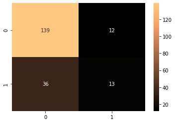

```
Training Accuracy: 1.000
Test Accuracy    : 0.760
```

```python
# define the parameter values that should be searched
parameters = {
    'weights': ['distance', 'uniform'],
    'n_neighbors': range(3, 11, 1),
}

# perform grid search using grid_search_function
grid_search_function(knnclf, 'K-Nearest-Neighbor', parameters, x_train_ssf, y_train, x_test_ssf, y_test, cv=10)
```

### Naive Bayes (Gaussian) Classifier:

The Naïve Bayes Classifier belongs to the family of probability classifier, using Bayesian theorem. The reason why it is called ‘Naïve’ because it requires rigid independence assumption between input variables. Therefore, it is more proper to call Simple Bayes or Independence Bayes. This algorithm has been studied extensively since 1960s. Simple though it is, Naïve Bayes Classifier remains one of popular methods to solve text categorization problem, the problem of judging documents as belonging to one category or the other, such as email spam detection.

Bayes’s theorem plays a critical role in probabilistic learning and classification.

- Uses prior probability of each class given no information about an item
- Classification produces a posterior probability distribution over the possible classes given a description of an item
- The models are incremental in the sense that each training example can incrementally increase or decrease the probability that a hypothesis is correct. Prior knowledge can be combined with observed data.

```python
nbclf = naive_bayes.GaussianNB()
print(nbclf.get_params())
```

```
{'priors': None, 'var_smoothing': 1e-09}
```

```
Wall time: 274 ms

{'priors': None, 'var_smoothing': 1e-09} 0.705

===============CLASSIFICATION REPORT===============
              precision    recall  f1-score   support

           N       0.86      0.72      0.78       151
           Y       0.42      0.63      0.51        49

    accuracy                           0.70       200
   macro avg       0.64      0.68      0.65       200
weighted avg       0.75      0.70      0.72       200


===============CONFUSION MATRIX===============
```

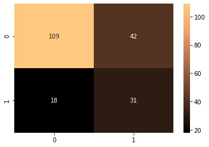

```
Training Accuracy: 0.762
Test Accuracy    : 0.700
```

```python
# define the parameter values that should be searched
parameters = {
    'priors': [None],
    'var_smoothing': [1e-09],
}

# perform grid search using grid_search_function
grid_search_function(nbclf, 'Naive Bayes (Gaussian)', parameters, x_train_ssf, y_train, x_test_ssf, y_test, cv=10)
```

### Decision Tree Classifier:

Decision Tree algorithm belongs to the family of supervised learning algorithms. In Decision Trees, for predicting a class label for a record we start from the root of the tree. We compare the values of the root attribute with the record’s attribute. On the basis of comparison, we follow the branch corresponding to that value and jump to the next node.

```python
dt = tree.DecisionTreeClassifier()
print(dt.get_params())
```

```
{'ccp_alpha': 0.0, 'class_weight': None, 'criterion': 'gini', 'max_depth': None, 'max_features': None, 'max_leaf_nodes': None, 'min_impurity_decrease': 0.0, 'min_impurity_split': None, 'min_samples_leaf': 1, 'min_samples_split': 2, 'min_weight_fraction_leaf': 0.0, 'presort': 'deprecated', 'random_st…
```

```
Wall time: 3min 24s

{'criterion': 'gini', 'max_depth': 3.0, 'min_samples_leaf': 1, 'min_samples_split': 0.30000000000000004} 0.85625

===============CLASSIFICATION REPORT===============
              precision    recall  f1-score   support

           N       0.96      0.83      0.89       151
           Y       0.63      0.90      0.74        49

    accuracy                           0.84       200
   macro avg       0.80      0.86      0.81       200
weighted avg       0.88      0.84      0.85       200


===============CONFUSION MATRIX===============
```

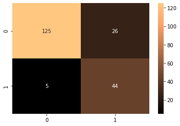

```
Training Accuracy: 0.856
Test Accuracy    : 0.845
```

```python
# define the parameter values that should be searched
parameters = {
    'criterion': ['gini', 'entropy'],
    'min_samples_split': np.linspace(0.1, 1.0, 10, endpoint=True),
    'max_depth': np.linspace(1, 10, 10, endpoint=True),
    'min_samples_leaf': range(1,6),
}

# perform grid search using grid_search_function
grid_search_function(dt, 'Decision Tree', parameters, x_train_ssf, y_train, x_test_ssf, y_test, cv=10)
```

```python
dtfinal = tree.DecisionTreeClassifier(criterion='gini', max_depth=3.0, min_samples_leaf=1, min_samples_split=0.30)
dtfinal.fit(x_train_ssf, y_train)

# call the predict function on the test intances to produce the predicted classes
treepreds = dtfinal.predict(x_test_ssf)

# print test accuracy
print('Test Accuracy: ', dtfinal.score(x_test_ssf, y_test))

# create a new dictionary with column names
dicT0 = {
    'gbpreds':treepreds,
    'actual':y_test,
}

# create a dataframe using a dictionary
preds0 = pd.DataFrame(dicT0)
preds0.head()
```

```
Test Accuracy:  0.845
```

|  | gbpreds | actual |
| --- | --- | --- |
| 286 | N | N |
| 402 | Y | Y |
| 253 | Y | Y |
| 4 | N | N |
| 372 | N | N |

#### Visualizing the decision tree:

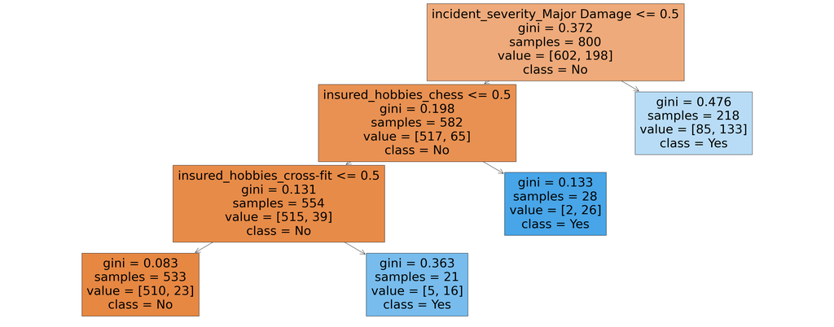

```python
fig, ax = plt.subplots(figsize=(50,20))
tree.plot_tree(dtfinal, feature_names=x_train_ssf.columns, class_names=["No","Yes"], filled=True, ax=ax);
```

A decision tree is a flow-chart-like tree structure:

- Internal node denotes a test on an attribute (feature)
- Branch represents an outcome of the test
- All records in a branch have the same value for the tested attribute
- Leaf node represents class label or class label distribution

```python
import graphviz
from sklearn.tree import export_graphviz

dot_data = export_graphviz(dtfinal,out_file=None, feature_names=x_train_ssf.columns,
                           class_names=["No","Yes"], filled=True, rotate=True)
graph = graphviz.Source(dot_data)
graph
```

[figure not shown]

#### Feature Importances

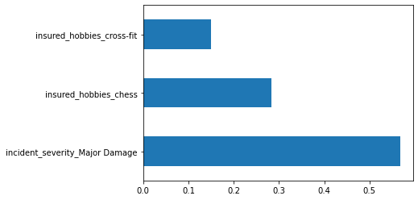

```python
(pd.Series(dtfinal.feature_importances_, index=x_train_ssf.columns)
   .nlargest(3)
   .plot(kind='barh'))
```

### Linear Discriminant Analysis (LDA) Classifier:

Linear discriminant analysis, normal discriminant analysis, or discriminant function analysis is a generalization of Fisher's linear discriminant, a method used in statistics and other fields, to find a linear combination of features that characterizes or separates two or more classes of objects or events. Wikipedia

```python
ldclf = LinearDiscriminantAnalysis()
print(ldclf.get_params())
```

```
{'n_components': None, 'priors': None, 'shrinkage': None, 'solver': 'svd', 'store_covariance': False, 'tol': 0.0001}
```

```
Wall time: 1min 7s

{'shrinkage': 0.052000000000000005, 'solver': 'lsqr'} 0.8450000000000001

===============CLASSIFICATION REPORT===============
              precision    recall  f1-score   support

           N       0.92      0.87      0.89       151
           Y       0.65      0.76      0.70        49

    accuracy                           0.84       200
   macro avg       0.78      0.81      0.79       200
weighted avg       0.85      0.84      0.84       200


===============CONFUSION MATRIX===============
```

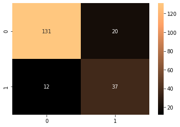

```
Training Accuracy: 0.885
Test Accuracy    : 0.840
```

```python
# define the parameter values that should be searched
parameters = {
    'solver': ['svd', 'lsqr', 'eigen'],
    'shrinkage': arange(0, 0.1, 0.001),
}

# perform grid search using grid_search_function
grid_search_function(ldclf, 'Linear Discriminant Analysis', parameters, x_train_ssf, y_train, x_test_ssf, y_test, cv=10)
```

### Rocchio Classifier:

The Rocchio algorithm is based on a method of relevance feedback found in information retrieval systems which stemmed from the SMART Information Retrieval System which was developed 1960-1964. Like many other retrieval systems, the Rocchio feedback approach was developed using the Vector Space Model. Wikipedia

```python
roclf = NearestCentroid()
print(roclf.get_params())
```

```
{'metric': 'euclidean', 'shrink_threshold': None}
```

```
Wall time: 30.8 s

{'metric': 'euclidean', 'shrink_threshold': 0.41000000000000003} 0.8125

===============CLASSIFICATION REPORT===============
              precision    recall  f1-score   support

           N       0.89      0.84      0.87       151
           Y       0.59      0.69      0.64        49

    accuracy                           0.81       200
   macro avg       0.74      0.77      0.75       200
weighted avg       0.82      0.81      0.81       200


===============CONFUSION MATRIX===============
```

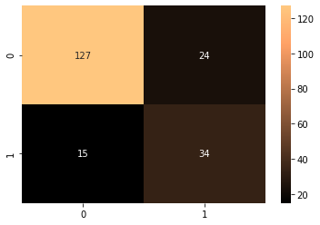

```
Training Accuracy: 0.816
Test Accuracy    : 0.805
```

```python
# define the parameter values that should be searched
parameters = {
    'metric': ['euclidean', 'manhattan'],
    'shrink_threshold': arange(0, 1.01, 0.01),
}

# perform grid search using grid_search_function
grid_search_function(roclf, 'Rocchio Classifier', parameters, x_train_ssf, y_train, x_test_ssf, y_test, cv=10)
```

### Random Forest Classifier (an example of bagging):

- Each classifier in the ensemble is a decision tree classifier and is generated using a random selection of attributes at each node to determine the split.
- During classification, each tree votes and the most popular class is returned.
- Comparable in accuracy to Adaboost, but more robust to errors and outliers.
- Insensitive to the number of attributes selected for consideration at each split, and faster than boosting.

```python
rf = RandomForestClassifier()
print(rf.get_params())
```

```
{'bootstrap': True, 'ccp_alpha': 0.0, 'class_weight': None, 'criterion': 'gini', 'max_depth': None, 'max_features': 'auto', 'max_leaf_nodes': None, 'max_samples': None, 'min_impurity_decrease': 0.0, 'min_impurity_split': None, 'min_samples_leaf': 1, 'min_samples_split': 2, 'min_weight_fraction_leaf'…
```

```
Wall time: 13min 22s

{'criterion': 'entropy', 'min_samples_split': 0.1, 'n_estimators': 5} 0.7899999999999999

===============CLASSIFICATION REPORT===============
              precision    recall  f1-score   support

           N       0.83      0.90      0.87       151
           Y       0.59      0.45      0.51        49

    accuracy                           0.79       200
   macro avg       0.71      0.67      0.69       200
weighted avg       0.78      0.79      0.78       200


===============CONFUSION MATRIX===============
```

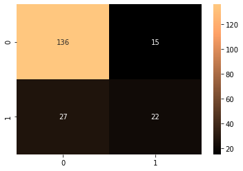

```
Training Accuracy: 0.830
Test Accuracy    : 0.790
```

```python
# define the parameter values that should be searched
parameters = {
    'n_estimators': range(5, 101, 5),
    'criterion': ['gini', 'entropy'],
    'min_samples_split': np.linspace(0.1, 1.0, 10, endpoint=True),
}

# perform grid search using grid_search_function
grid_search_function(rf, 'Random Forest', parameters, x_train_ssf, y_train, x_test_ssf, y_test, cv=10)
```

### Ada Boost Classifier:

AdaBoost, short for “Adaptive Boosting”, is the first practical boosting algorithm proposed by Freund and Schapire in 1996. It focuses on classification problems and aims to convert a set of weak classifiers into a strong one.

```python
ab = AdaBoostClassifier()
print(ab.get_params())
```

```
{'algorithm': 'SAMME.R', 'base_estimator': None, 'learning_rate': 1.0, 'n_estimators': 50, 'random_state': None}
```

```
Wall time: 5min 32s

{'learning_rate': 1.8, 'n_estimators': 10} 0.8362499999999999

===============CLASSIFICATION REPORT===============
              precision    recall  f1-score   support

           N       0.93      0.83      0.87       151
           Y       0.60      0.80      0.68        49

    accuracy                           0.82       200
   macro avg       0.76      0.81      0.78       200
weighted avg       0.85      0.82      0.83       200


===============CONFUSION MATRIX===============
```

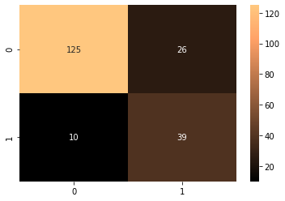

```
Training Accuracy: 0.843
Test Accuracy    : 0.820
```

```python
# define the parameter values that should be searched
parameters = {
    'learning_rate': [0.01, 0.05, 0.1, 0.2, 0.3, 0.4, 0.6, 0.7, 0.8, 0.9, 1.0, 1.3, 1.5, 1.8, 2.0],
    'n_estimators': range(5, 51, 5),
}

# perform grid search using grid_search_function
grid_search_function(ab, 'Ada Boost', parameters, x_train_ssf, y_train, x_test_ssf, y_test, cv=10)
```

### Gradient Boosting Classifier:

The following is an example of using Gradient Boosted Decision Trees. GBDT is a generalization of boosting to arbitrary differentiable loss functions. GBDT is an accurate and effective procedure that can be used for both regression and classification.

Analogy: Consult several doctors, based on a combination of weighted diagnoses—weight assigned based on the previous diagnosis accuracy

How boosting works?

- Weights are assigned to each training tuple
- A series of k classifiers is iteratively learned
- After a classifier Mi is learned, the weights are updated to allow the subsequent classifier, Mi+1 , to pay more attention to the training tuples that were misclassified by Mi
- The final M* combines the votes of each individual classifier, where the weight of each classifier's vote is a function of its accuracy

Boosting algorithm can be extended for numeric prediction. Compared to bagging: Boosting tends to have greater accuracy, but it also risks overfitting the model to misclassified data

```python
gb = GradientBoostingClassifier()
print(gb.get_params())
```

```
{'ccp_alpha': 0.0, 'criterion': 'friedman_mse', 'init': None, 'learning_rate': 0.1, 'loss': 'deviance', 'max_depth': 3, 'max_features': None, 'max_leaf_nodes': None, 'min_impurity_decrease': 0.0, 'min_impurity_split': None, 'min_samples_leaf': 1, 'min_samples_split': 2, 'min_weight_fraction_leaf': 0…
```

```
Wall time: 5min 25s

{'learning_rate': 1.5, 'n_estimators': 5, 'random_state': 0} 0.8375

===============CLASSIFICATION REPORT===============
              precision    recall  f1-score   support

           N       0.96      0.85      0.91       151
           Y       0.67      0.90      0.77        49

    accuracy                           0.86       200
   macro avg       0.81      0.88      0.84       200
weighted avg       0.89      0.86      0.87       200


===============CONFUSION MATRIX===============
```

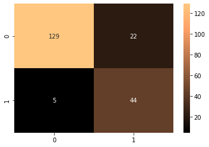

```
Training Accuracy: 0.877
Test Accuracy    : 0.865
```

```python
# define the parameter values that should be searched
parameters = {
    'learning_rate': [0.01, 0.05, 0.1, 0.2, 0.3, 0.4, 0.6, 0.7, 0.8, 0.9, 1.0, 1.3, 1.5, 1.8, 2.0],
    'n_estimators': range(5, 51, 5),
    'random_state': [0],
}

# perform grid search using grid_search_function
grid_search_function(gb, 'Gradient Boosting', parameters, x_train_ssf, y_train, x_test_ssf, y_test, cv=10)
```

```python
gbfinal = GradientBoostingClassifier(learning_rate=1.5, n_estimators=5, random_state=0)
gbfinal.fit(x_train_ssf, y_train)

# call the predict function on the test intances to produce the predicted classes
gbpreds = gbfinal.predict(x_test_ssf)

# print test accuracy
print('Test Accuracy: ', gbfinal.score(x_test_ssf, y_test))

# create a new dictionary with column names
dicT1 = {
    'gbpreds':gbpreds,
    'actual':y_test,
}

# create a dataframe using a dictionary
preds1 = pd.DataFrame(dicT1)
preds1.head()
```

```
Test Accuracy:  0.865
```

|  | gbpreds | actual |
| --- | --- | --- |
| 286 | N | N |
| 402 | Y | Y |
| 253 | Y | Y |
| 4 | N | N |
| 372 | N | N |

#### Feature Importances

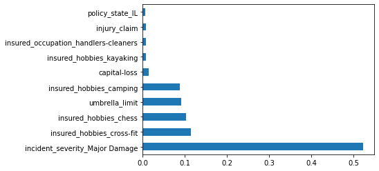

```python
(pd.Series(gbfinal.feature_importances_, index=x_train_ssf.columns)
   .nlargest(10)
   .plot(kind='barh'))
```

### Support Vector Machines (SVC Classifier):

Many classification models, such as Naïve Bayes, try to model the distribution of each class, and use these models to determine labels for new points. Sometimes called generative classification models.

SVMs are discriminative classification models: Rather than modeling each class, they simply find a line or curve (in two dimensions) or a manifold (in multiple dimensions) that divides the classes from each other.

```python
svc = SVC()
print(svc.get_params())
```

```
{'C': 1.0, 'break_ties': False, 'cache_size': 200, 'class_weight': None, 'coef0': 0.0, 'decision_function_shape': 'ovr', 'degree': 3, 'gamma': 'scale', 'kernel': 'rbf', 'max_iter': -1, 'probability': False, 'random_state': None, 'shrinking': True, 'tol': 0.001, 'verbose': False}
```

```
Wall time: 21min 6s

{'C': 5, 'degree': 1, 'kernel': 'poly'} 0.8525

===============CLASSIFICATION REPORT===============
              precision    recall  f1-score   support

           N       0.90      0.85      0.88       151
           Y       0.61      0.71      0.66        49

    accuracy                           0.82       200
   macro avg       0.76      0.78      0.77       200
weighted avg       0.83      0.82      0.82       200


===============CONFUSION MATRIX===============
```

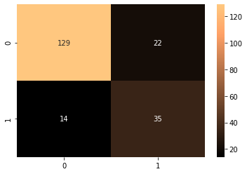

```
Training Accuracy: 0.882
Test Accuracy    : 0.820
```

```python
# define the parameter values that should be searched
parameters = {
    'degree': range(1,11),
    'kernel': ['linear', 'poly', 'rbf', 'sigmoid'],
    'C': [1, 5, 10, 50, 100],
}

# perform grid search using grid_search_function
grid_search_function(svc, 'Support Vector Machines', parameters, x_train_ssf, y_train, x_test_ssf, y_test, cv=10)
```

### Logistic Regression Classifier:

Logistic regression is a classification algorithm, used when the value of the target variable is categorical in nature. Logistic regression is most commonly used when the data in question has binary output, so when it belongs to one class or another, or is either a 0 or 1.

```python
lr = LogisticRegression()
print(lr.get_params())
```

```
{'C': 1.0, 'class_weight': None, 'dual': False, 'fit_intercept': True, 'intercept_scaling': 1, 'l1_ratio': None, 'max_iter': 100, 'multi_class': 'auto', 'n_jobs': None, 'penalty': 'l2', 'random_state': None, 'solver': 'lbfgs', 'tol': 0.0001, 'verbose': 0, 'warm_start': False}
```

```
Wall time: 2min 36s

{'l1_ratio': 0.0001, 'penalty': 'l2'} 0.8125

===============CLASSIFICATION REPORT===============
              precision    recall  f1-score   support

           N       0.87      0.89      0.88       151
           Y       0.63      0.59      0.61        49

    accuracy                           0.81       200
   macro avg       0.75      0.74      0.74       200
weighted avg       0.81      0.81      0.81       200


===============CONFUSION MATRIX===============
```

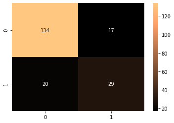

```
Training Accuracy: 0.891
Test Accuracy    : 0.815
```

```python
# define the parameter values that should be searched
parameters = {
    'l1_ratio': np.linspace(0.0001, 100, 200),
    'penalty': ['l1', 'l2', 'elasticnet'],
}

# perform grid search using grid_search_function
grid_search_function(lr, 'Logistic Regression', parameters, x_train_ssf, y_train, x_test_ssf, y_test, cv=10)
```

### Performance of Different Models:

```python
# create a new dictionary with column names
dicT = {
    'Model':modeL,
    'GSCV_BestScore':gsCV_BestScore,
    'Train_Accuracy':train_accuracy,
    'Test_Accuracy':test_accuracy,
}

# create a dataframe using a dictionary
models_matrix = pd.DataFrame(dicT)

# set Model column as index of the dataframe
models_matrix = models_matrix.set_index('Model')

# Sort the dataframe by Test_Accuracy
models_matrix.sort_values(by=['Test_Accuracy'], ascending=False)
```

| Model | GSCV_BestScore | Train_Accuracy | Test_Accuracy |
| --- | --- | --- | --- |
| Gradient Boosting | 0.84 | 0.88 | 0.86 |
| Decision Tree | 0.86 | 0.86 | 0.84 |
| Linear Discriminant Analysis | 0.85 | 0.89 | 0.84 |
| Ada Boost | 0.84 | 0.84 | 0.82 |
| Support Vector Machines | 0.85 | 0.88 | 0.82 |
| Logistic Regression | 0.81 | 0.89 | 0.81 |
| Rocchio Classifier | 0.81 | 0.82 | 0.81 |
| Random Forest | 0.79 | 0.83 | 0.79 |
| K-Nearest-Neighbor | 0.77 | 1.00 | 0.76 |
| Naive Bayes (Gaussian) | 0.70 | 0.76 | 0.70 |

### Conclusion:

In above table, the accuracy of the different models were compared to select the final model for prediction. The Gradient Boosting model was selected based on its performance. It had the highest test accuracy rate of 0.865. The future recommendation is to test and run this model in real time on a bigger dataset, since our dataset had only around 1000 instances. This model can flag potential fraud in insurance claims and can lead to reduction in insurance premiums, claim turnaround time, and increase company’s profitability.